# Regression 2

February 17 2026

## Topics for this lecture

- Predictions (with uncertainty)
- Significance of regression, the F-test
- Interaction effects
- Model checking
- Polynomial regression
- Transformations of the response
- Variable selection

## The body data

Let’s again look at the body data and the model: \[ y_i = \beta_0 + \beta_1 x_{1i} + \beta_2 x_{2i} + \beta_3 x_{3i}+\epsilon_i \] with the usual assumption of independent errors distributed as \(\epsilon_i \sim N(0, \sigma^2)\). Here \(y_i\) is the body weight of person \(i\), \(x_{1i}\) the height, \(x_{2i}\) is the circumference and \(x_{3i}\) is the age of the same person.

## Our model with 3 predictors

```
##
## Call:
## lm(formula = Weight ~ Height + Circumference + Age, data = bodydata,
##     subset = 1:20)
##
## Residuals:
##     Min      1Q  Median      3Q     Max
## -5.4088 -3.3900 -0.9123  3.0403  6.9827
##
## Coefficients:
##               Estimate Std. Error t value Pr(>|t|)
## (Intercept)   -66.5785    30.0098  -2.219 0.041330 *
## Height          0.4768     0.1600   2.981 0.008831 **
## Circumference   0.7769     0.1858   4.181 0.000706 ***
## Age            -0.2094     0.3731  -0.561 0.582352
## ---
## Signif. codes:  0 '***' 0.001 '**' 0.01 '*' 0.05 '.' 0.1 ' ' 1
##
## Residual standard error: 4.259 on 16 degrees of freedom
## Multiple R-squared:  0.6852, Adjusted R-squared:  0.6262
## F-statistic: 11.61 on 3 and 16 DF,  p-value: 0.0002729
```

## Prediction

A fitted model can be used for prediction of new observations

According to model 4, what is the predicted Weight of some person with these values?

```
##   Height Circumference Age
## 1    171            76  30
```

\(\widehat{y} = -66.579 + 0.4768\cdot171 + 0.7769\cdot76 - 0.2094\cdot30\)

\(= 67.72\)

```r
newobs <- data.frame('Height'=171, 'Circumference'=76, 'Age'=30)
predict.lm(LinearModel.4, newdata=newobs)
```

```
##       1
## 67.7196
```

## Confidence in predictions

**Confidence interval for** \(E(Y|x_1, \ldots, x_p) \in \widehat{\mu}(\mathbf{x}_{\text{new}}) \pm t_{\alpha/2,\,n-p-1} \cdot \text{SE}(\widehat{\mu}(\mathbf{x}_{\text{new}}))\) where \(\text{SE}(\widehat{\mu}(\mathbf{x}_{\text{new}}))\) accounts for uncertainty in estimation.

```r
predict.lm(LinearModel.4, newobs, level=0.95, interval=c("confidence"))
```

```
##       fit      lwr      upr
## 1 67.7196 60.98252 74.45668
```

**Prediction interval for** \(Y|x_1, \ldots, x_p \in \widehat{\mu}(\mathbf{x}_{\text{new}}) \pm t_{\alpha/2,\,n-p-1}\,\text{SE}_{\text{pred}}\)

```r
predict.lm(LinearModel.4, newobs, level=0.95, interval=c("prediction"))
```

```
##       fit      lwr      upr
## 1 67.7196 56.45463 78.98456
```

## Predicted vs observed - plot

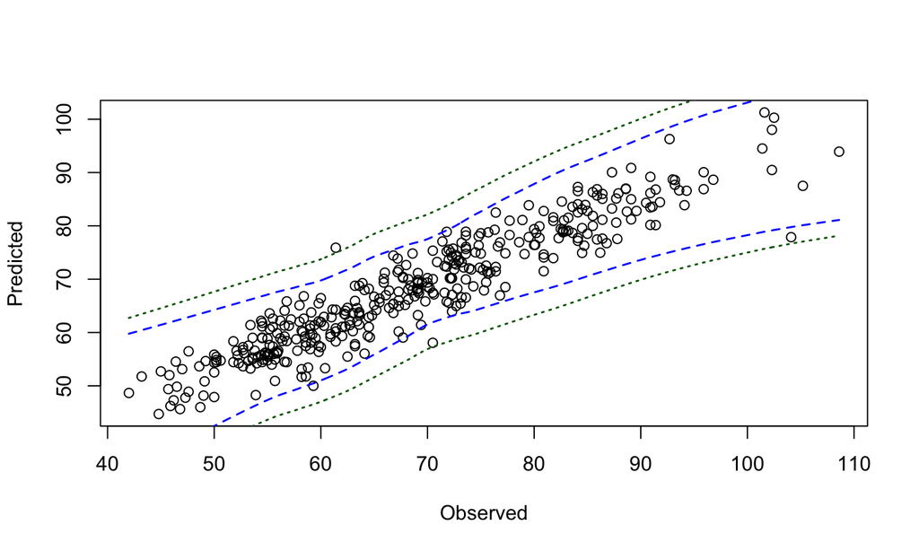

## Check predictions’ errors

```
##         fit      lwr      upr
## 25 73.94436 64.06824 83.82047
## 26 82.80148 72.72603 92.87693
## 27 81.03059 71.44393 90.61725
## 28 71.46852 61.81893 81.11811
## 29 65.93065 55.27452 76.58677
## 31 76.31124 66.90951 85.71296
## 32 69.35871 59.61763 79.09979
## 33 75.73802 65.67258 85.80346
## 34 82.52507 72.84459 92.20555
## 35 67.71321 57.86212 77.56431
## 37 73.86325 64.29154 83.43496
## 39 74.81258 65.46899 84.15617
```

```
## [1] " RMSE  observed: 3.8092"
```

```
## [1] " RMSE  predictions: 4.8026"
```

## Checking the prediction intervals

How many observations fell within the prediction intervals?

```r
largerthanlower <- (newWeight > pred[,2])
smallerthanupper <- (newWeight < pred[,3])
inInterval <- which(largerthanlower & smallerthanupper)
print(length(inInterval))
```

```
## [1] 381
```

Proportion of observations within prediction intervals:

```r
length(inInterval)/length(newWeight)
```

```
## [1] 0.9844961
```

What should we expect?

## SSE, SST, SSR again

- Total Sum of Squares: \(SST = \sum_{i=1}^n (y_i - \bar{y})^2\)
- Error Sum of Squares: \(SSE = \sum_{i=1}^n (y_i - \widehat{\mu}(x_i))^2\)
- Regression Sum of Squares: \(SSR = \sum_{i=1}^n (\widehat{\mu}(x_i) - \bar{y})^2\)

  It can be shown:

\(SST = SSE + SSR \quad \Rightarrow\quad R^2 = 1 - \frac{SSE}{SST} = \frac{SSR}{SST}\)

## Significance of regression?

We have seen how we can test the significance of single predictor terms with T-tests in the previous lesson.

We may also test the overall significance of the regression model.

Recall from earlier that \(R^2 = 1-\frac{SSE}{SST} = \frac{SSR}{SST}\) is a measure of model fit. If the model can explain much of the observed variability in \(y\), then SSR is close to SST and big compared to SSE.

Can be shown that a convenient test observator, typically named \(F\) (for Fisher) is:

\[F = \frac{SSR/p}{SSE/(n-p-1)}\]

## The F-test for overall significance of regression

Hypothesis:

\(H_0: \beta_1 = \beta_2 = \cdots = \beta_p = 0\) vs \(H_1:\) at least one \(\beta_j \neq 0\).

Reject the null hypothesis at test level \(\alpha\) if \(F\) is large, and more specifically if

\(F > F_{\alpha, p, n-p-1}\)

Let’s see how this turns out for the body data model.

## The F-test illustration

## Recall

```
##
## Call:
## lm(formula = Weight ~ Height + Circumference + Age, data = bodydata,
##     subset = 1:20)
##
## Residuals:
##     Min      1Q  Median      3Q     Max
## -5.4088 -3.3900 -0.9123  3.0403  6.9827
##
## Coefficients:
##               Estimate Std. Error t value Pr(>|t|)
## (Intercept)   -66.5785    30.0098  -2.219 0.041330 *
## Height          0.4768     0.1600   2.981 0.008831 **
## Circumference   0.7769     0.1858   4.181 0.000706 ***
## Age            -0.2094     0.3731  -0.561 0.582352
## ---
## Signif. codes:  0 '***' 0.001 '**' 0.01 '*' 0.05 '.' 0.1 ' ' 1
##
## Residual standard error: 4.259 on 16 degrees of freedom
## Multiple R-squared:  0.6852, Adjusted R-squared:  0.6262
## F-statistic: 11.61 on 3 and 16 DF,  p-value: 0.0002729
```

## The body data

```r
body1 <- lm(Weight ~  Height + Circumference + Age, data=bodydata, subset = 1:20)
Atab <- anova(body1)
```

```
## Analysis of Variance Table
##
## Response: Weight
##               Df Sum Sq Mean Sq F value    Pr(>F)
## Height         1 308.31  308.31 16.9984 0.0007973 ***
## Circumference  1 317.76  317.76 17.5190 0.0006993 ***
## Age            1   5.72    5.72  0.3151 0.5823519
## Residuals     16 290.20   18.14
## ---
## Signif. codes:  0 '***' 0.001 '**' 0.01 '*' 0.05 '.' 0.1 ' ' 1
```

```
##  SST =  921.988 , SSR =  631.7836 ;
##  Cummulative SST 308.3131 626.0686 631.7836 921.988 ;
##  F =  11.61083
```

## The body data - Compare with previous

```r
body1 <- lm(Weight ~   Circumference + Height + Age, data=bodydata, subset = 1:20)
Atab <- anova(body1)
```

```
## Analysis of Variance Table
##
## Response: Weight
##               Df Sum Sq Mean Sq F value    Pr(>F)
## Circumference  1 467.18  467.18 25.7575 0.0001125 ***
## Height         1 158.89  158.89  8.7599 0.0092221 **
## Age            1   5.72    5.72  0.3151 0.5823519
## Residuals     16 290.20   18.14
## ---
## Signif. codes:  0 '***' 0.001 '**' 0.01 '*' 0.05 '.' 0.1 ' ' 1
```

```
## SST =  921.988 , SSR =  631.7836 , F =  11.61083
```

## Interaction effects

Interaction effects occur when the effect of one variable on the response variable depends on the level/value of another variable.

Consider the model: \[ y_i = \beta_0 + \beta_1 x_{1i} + \beta_2 x_{2i} + \beta_3 x_{3i} + \beta_4 x_{2i}x_{3i} + \epsilon_i \]

here we have expanded the model with an interaction term between \(x_2\) and \(x_3\) (between circumference and age). How should we interpret this model?

## How to fit the model in RStudio

Now fit on all the data we have

```r
data(bodydata)
body2 <- lm(Weight ~ Height + Circumference + Age +
              Circumference:Age, data=bodydata)
summary(body2)
```

## The output with all data

```
##
## Call:
## lm(formula = Weight ~ Height + Circumference + Age + Circumference:Age,
##     data = bodydata)
##
## Residuals:
##      Min       1Q   Median       3Q      Max
## -15.1735  -2.5820  -0.1732   2.6033  22.5148
##
## Coefficients:
##                     Estimate Std. Error t value Pr(>|t|)
## (Intercept)       -93.579875   6.030390 -15.518  < 2e-16 ***
## Height              0.414057   0.027243  15.199  < 2e-16 ***
## Circumference       1.244437   0.070990  17.530  < 2e-16 ***
## Age                 0.611383   0.159085   3.843 0.000141 ***
## Circumference:Age  -0.009476   0.001990  -4.763 2.67e-06 ***
## ---
## Signif. codes:  0 '***' 0.001 '**' 0.01 '*' 0.05 '.' 0.1 ' ' 1
##
## Residual standard error: 4.252 on 402 degrees of freedom
## Multiple R-squared:  0.8989, Adjusted R-squared:  0.8979
## F-statistic: 893.8 on 4 and 402 DF,  p-value: < 2.2e-16
```

## Model checking

In standard linear regression we typically assume:

- Linearity
- Constant variance
- Independent observations
- Normality

We should check that these assumptions are OK. Typically we do this by examining the residuals

## Residual plots

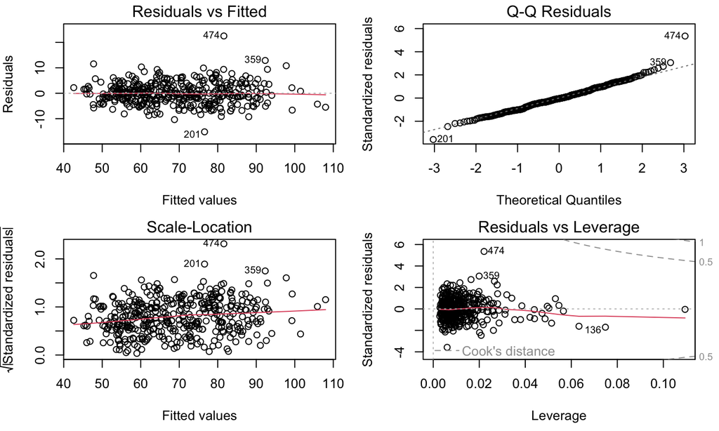

```r
par(mfrow=c(2,2), mar=c(4.5,4,1.5,1.5))
plot(body2, ask=FALSE)
```

## Draw Q-Q plot and std residuals

## Another example - Bears

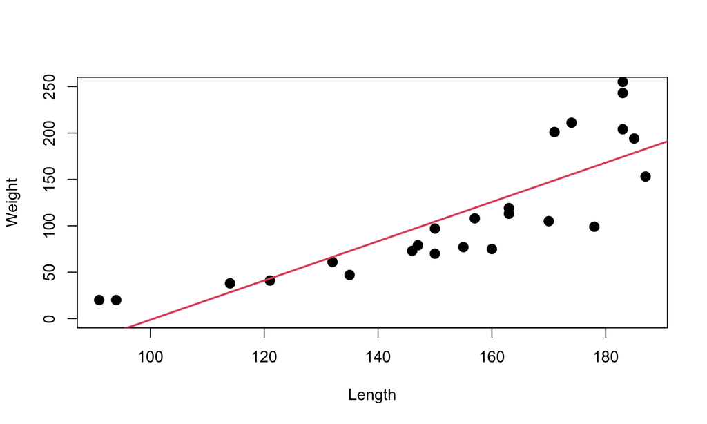

## Summary

```
##
## Call:
## lm(formula = Weight ~ Length, data = bears)
##
## Residuals:
##    Min     1Q Median     3Q    Max
## -64.76 -26.78  -9.42  30.74  80.67
##
## Coefficients:
##              Estimate Std. Error t value Pr(>|t|)
## (Intercept) -212.8522    47.2818  -4.502 0.000177 ***
## Length         2.1158     0.3027   6.989 5.15e-07 ***
## ---
## Signif. codes:  0 '***' 0.001 '**' 0.01 '*' 0.05 '.' 0.1 ' ' 1
##
## Residual standard error: 40.1 on 22 degrees of freedom
## Multiple R-squared:  0.6895, Adjusted R-squared:  0.6754
## F-statistic: 48.85 on 1 and 22 DF,  p-value: 5.147e-07
```

## Residual plots

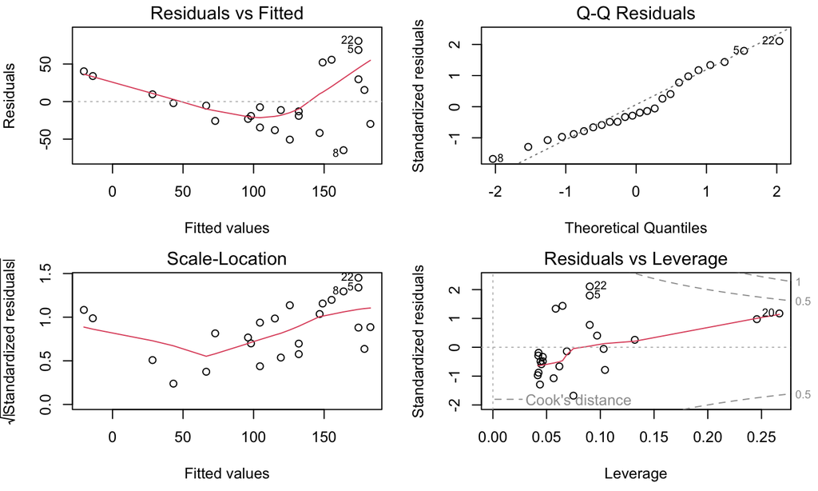

```r
par(mfrow=c(2,2), mar=c(4.5,4,1.5,1.5))
plot(bears1, ask=FALSE)
```

## Outliers and influence statistics

- Leverage
- Standardized residuals
- Deleted residuals (PRESS residuals) (predict the deleted leave out one point)
- Cook’s distance (combines leverage and standardized residuals) > 1, can be dangerous

## Explain leverage

## Polynomial regression

Non-linear relationships may be modelled by polynomial regression.

Bear example

- \(y=\) Weight
- \(x_1\) = Length
- \(x_1^2\) = Length\(^2\)

A multiple LINEAR model (linear in the \(\beta\)’s)

\[y = \beta_0 + \beta_1 x_1 + \beta_2 x_1^2 + \epsilon\]

## Fitting the model in R

```r
bears2 <- lm(Weight ~ Length + I(Length^2), data=bears)
summary(bears2)
```

```
##
## Call:
## lm(formula = Weight ~ Length + I(Length^2), data = bears)
##
## Residuals:
##     Min      1Q  Median      3Q     Max
## -75.411 -10.514  -1.302  11.809  60.075
##
## Coefficients:
##               Estimate Std. Error t value Pr(>|t|)
## (Intercept) 291.623760 175.892266   1.658  0.11219
## Length       -5.289645   2.525406  -2.095  0.04852 *
## I(Length^2)   0.026018   0.008825   2.948  0.00768 **
## ---
## Signif. codes:  0 '***' 0.001 '**' 0.01 '*' 0.05 '.' 0.1 ' ' 1
##
## Residual standard error: 34.52 on 21 degrees of freedom
## Multiple R-squared:  0.7804, Adjusted R-squared:  0.7595
## F-statistic: 37.31 on 2 and 21 DF,  p-value: 1.223e-07
```

## A fitted line plot

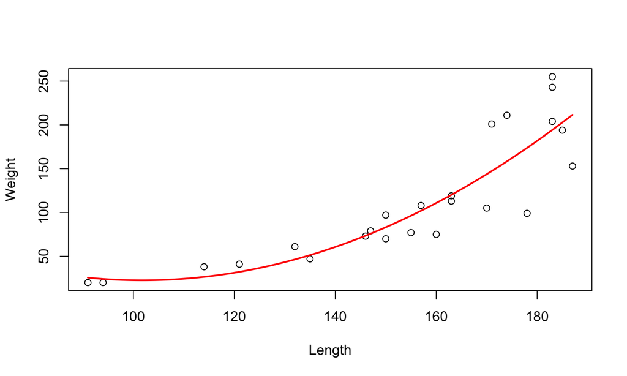

## Model checking

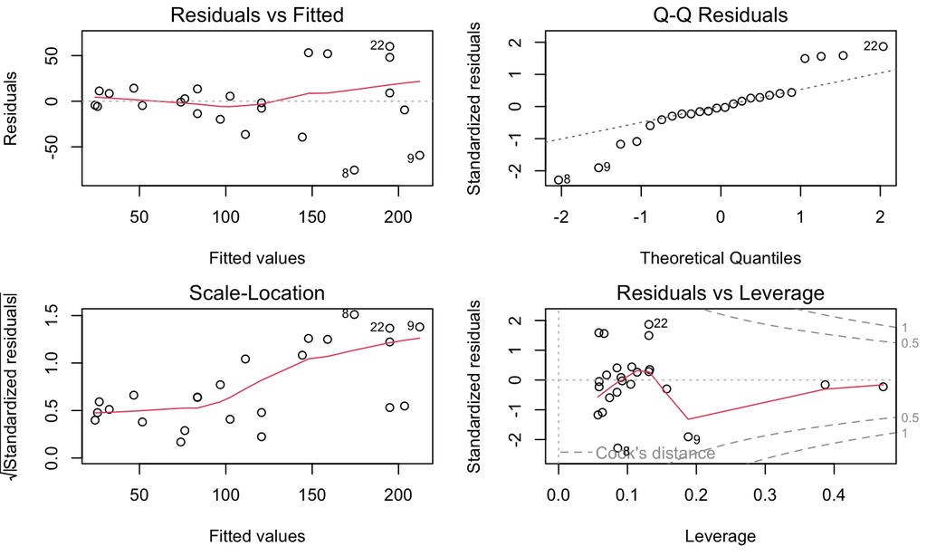

```r
par(mfrow=c(2,2), mar=c(4.5,4,1.5,1.5))
plot(bears2, ask=FALSE)
```

## Careful! Over-fitting!

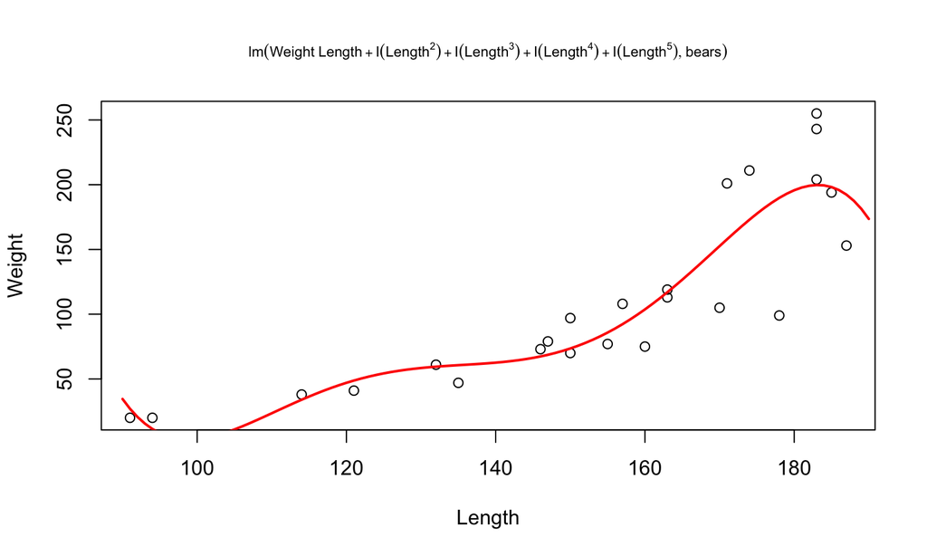

## Careful! Over-fitting!

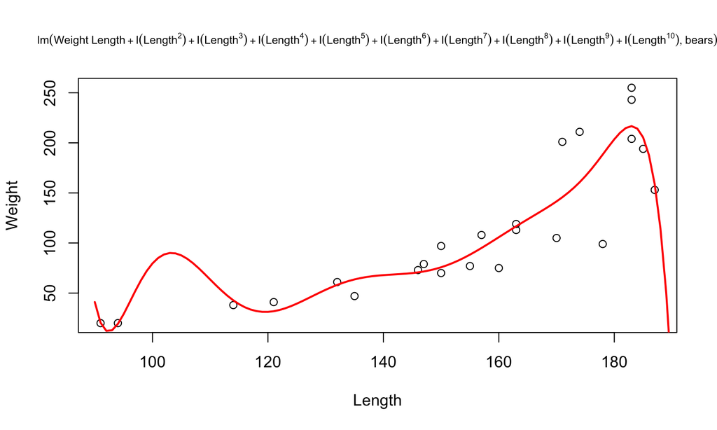

## Careful! Over-fitting!

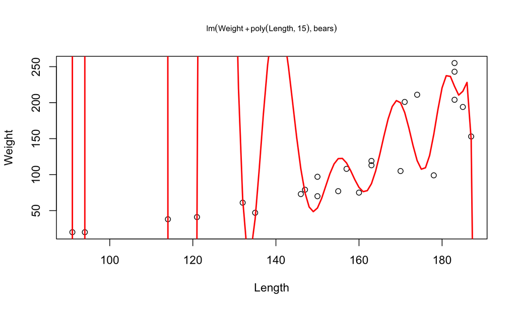

## Transformations

Deviations from model assumptions may be fixed by transforming \(y\) and/or \(x\).

Some transformations which may improve linearity and stabilize variance are

- \(\widetilde{y} = log(y)\)
- \(\widetilde{x} = log(x)\)
- \(\widetilde{y} = \sqrt{y}\)

Then use \(\widetilde{y}\) and/or \(\widetilde{x}\) instead of \(y\) and \(x\) to fit the model

## The log(Weight) response model

```r
bears4 <- lm(log(Weight) ~ Length, data=bears)
summary(bears4)
```

```
##
## Call:
## lm(formula = log(Weight) ~ Length, data = bears)
##
## Residuals:
##      Min       1Q   Median       3Q      Max
## -0.50918 -0.17192  0.02291  0.11978  0.37173
##
## Coefficients:
##             Estimate Std. Error t value Pr(>|t|)
## (Intercept) 0.712120   0.268342   2.654   0.0145 *
## Length      0.024675   0.001718  14.363 1.17e-12 ***
## ---
## Signif. codes:  0 '***' 0.001 '**' 0.01 '*' 0.05 '.' 0.1 ' ' 1
##
## Residual standard error: 0.2276 on 22 degrees of freedom
## Multiple R-squared:  0.9036, Adjusted R-squared:  0.8992
## F-statistic: 206.3 on 1 and 22 DF,  p-value: 1.173e-12
```

## Explain the transformation and back-transformation

## Residual plots

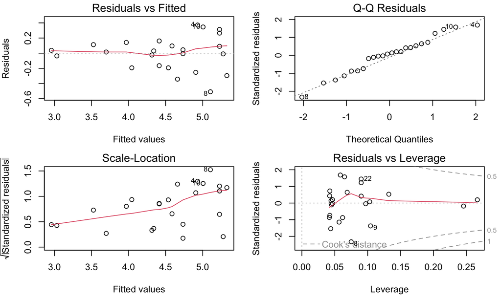

```r
par(mfrow=c(2,2), mar=c(4.5,4,1.5,1.5))
plot(bears4, ask=FALSE)
```

## A fitted line plot

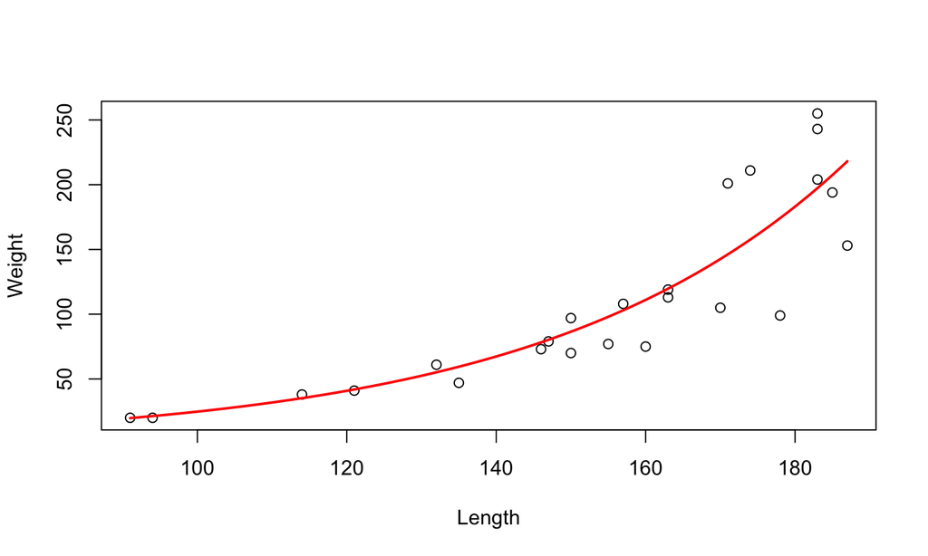

## Variable selection

Variable selection is the process of selecting a subset of variables that are most relevant for the response in some way. Various approaches. Some are based on hypothesis testing, some on criteria (like Akaike’s Information Criteria - AIC, Bayesian information criterion - BIC, adjuseted \(R^2_{adj}\), etc)

Sometimes combined with stepwise approaches like:

- Forward selection
- Backward selection
- Forward/Backward
- Backward/Forward
- All subsets selection

```r
library(mixlm)
```

## Stepwise methods - Backward selection

```r
body1 <- lm(Weight ~ Height + Circumference + Age, data=bodydata, subset=1:50)
bs <- backward(body1, alpha=0.05)
```

```
## Backward elimination, alpha-to-remove: 0.05
##
## Full model: Weight ~ Height + Circumference + Age
##
##     Step    RSS    AIC  R2pred     Cp F value Pr(>F)
## Age    1 964.52 153.98 0.71627 3.3702  1.3702 0.2478
```

## Stepwise methods - Backward selection

```r
summary(bs)
```

```
##
## Call:
## lm(formula = Weight ~ Height + Circumference, data = bodydata,
##     subset = 1:50)
##
## Residuals:
##     Min      1Q  Median      3Q     Max
## -9.6399 -2.5548  0.2676  3.1122  9.9851
##
## Coefficients:
##                Estimate Std. Error t value Pr(>|t|)
## (Intercept)   -88.77490   16.95517  -5.236 3.77e-06 ***
## Height          0.43630    0.09669   4.512 4.28e-05 ***
## Circumference   1.09158    0.11835   9.223 4.07e-12 ***
## ---
## Signif. codes:  0 '***' 0.001 '**' 0.01 '*' 0.05 '.' 0.1 ' ' 1
##
## s: 4.53 on 47 degrees of freedom
## Multiple R-squared: 0.7534,
## Adjusted R-squared: 0.7429
## F-statistic: 71.78 on 2 and 47 DF,  p-value: 5.171e-15
```

## Stepwise methods - Forward selection

```r
body1 <- lm(Weight ~ Height + Circumference + Age, data=bodydata, subset=1:50)
fs <- forward(body1, alpha=0.05)
```

```
## Forward selection, alpha-to-enter: 0.05
##
## Full model: Weight ~ Height + Circumference + Age
##
##               Step     RSS    AIC  R2pred      Cp F value    Pr(>F)
## Circumference    1 1382.37 169.98 0.60830 21.8918  87.788 2.043e-12 ***
## Height           2  964.52 153.98 0.71627  3.3702  20.361 4.281e-05 ***
## ---
## Signif. codes:  0 '***' 0.001 '**' 0.01 '*' 0.05 '.' 0.1 ' ' 1
```

## Stepwise methods - Forward selection

```r
summary(fs)
```

```
##
## Call:
## lm(formula = Weight ~ Circumference + Height, data = bodydata,
##     subset = 1:50)
##
## Residuals:
##     Min      1Q  Median      3Q     Max
## -9.6399 -2.5548  0.2676  3.1122  9.9851
##
## Coefficients:
##                Estimate Std. Error t value Pr(>|t|)
## (Intercept)   -88.77490   16.95517  -5.236 3.77e-06 ***
## Circumference   1.09158    0.11835   9.223 4.07e-12 ***
## Height          0.43630    0.09669   4.512 4.28e-05 ***
## ---
## Signif. codes:  0 '***' 0.001 '**' 0.01 '*' 0.05 '.' 0.1 ' ' 1
##
## s: 4.53 on 47 degrees of freedom
## Multiple R-squared: 0.7534,
## Adjusted R-squared: 0.7429
## F-statistic: 71.78 on 2 and 47 DF,  p-value: 5.171e-15
```

## Best subsets method

If the number of candidate variables, \(p\), is limited, e.g. \(\leq20\), we may compare all possible models

There are \(2^p\) possible models

Compare all model fits by AIC, BIC, \(R^2_{adj}\)

Choose model based on:

- Best-fit - simplicity trade-off

## Best subsets method - Example

```r
body1 <- lm(Weight ~ Height + Circumference + Age, data=bodydata, subset=1:50)
bs <- best.subsets(body1)
```

[output not shown]